# My Expenses Data Exploration

This tiny dataset which contains about more than 1000 rows with 9 variables each has information about my expenses from April 2015 to till date. This dataset is obtained from an andriod app “Walnut”, which is a expense tracker.

## 1. Loading The Datadet And Required Imports

```r
library(dplyr)
library(ggplot2)
library(plotly)
setwd("E:/MOOC")
expensesTemp <- read.csv("walnut.csv",stringsAsFactors=FALSE)
```

## 2. Dimensions Of The Dataset

```r
dim(expensesTemp)
```

```
## [1] 1217    9
```

## 3. Description of the variables and their types.

```r
str(expensesTemp)
```

```
## 'data.frame':    1217 obs. of  9 variables:
##  $ DATE    : chr  "24-04-15" "12-06-15" "12-06-15" "12-06-15" ...
##  $ TIME    : chr  "10:42 AM" "07:16 AM" "11:05 AM" "02:15 PM" ...
##  $ PLACE   : chr  "OLA" "NET BANKING" "INDIAN RAILWAY" "NET BANKING" ...
##  $ AMOUNT  : chr  "227" "330" "-515" "12" ...
##  $ ACCOUNT : chr  "OlaCab Messages" "Allahbad Bk  5992" "IRCTC Messages" "Allahbad Bk  5992" ...
##  $ EXPENSE : chr  "No" "No" "No" "No" ...
##  $ CATEGORY: chr  "UNKNOWN" "UNKNOWN" "UNKNOWN" "UNKNOWN" ...
##  $ TAGS    : chr  "" "" "" "" ...
##  $ NOTE    : chr  "" "" "Indian Railway refund" "" ...
```

## 4. Data Cleaning

As part of data cleaning, lets remove some unnecessary columns and transform some variables like date and amount from chr variables to date and number variables. The Account variable contains some sensitive information like last 4 digits of my debit and credit cards, so I am removing that variable from the dataframe.

Apart from removing some columns, I have added columns like year and month to track year-wise and month-wise expenses.

```r
expensesTemp <- subset(expensesTemp,select = -c(NOTE,TIME,ACCOUNT,TAGS))
expensesTemp$DATE <- as.Date(expensesTemp$DATE,format='%d-%m-%y')
expensesTemp$MONTH <- as.factor(format(expensesTemp$DATE,'%b'))
expensesTemp$YEAR<- as.factor(format(expensesTemp$DATE,'%Y'))
expensesTemp$PLACE <- as.factor(expensesTemp$PLACE)
expensesTemp$EXPENSE <- as.factor(expensesTemp$EXPENSE)
expensesTemp$CATEGORY <- ifelse(expensesTemp$CATEGORY == "","UNKNOWN",expensesTemp$CATEGORY)
expensesTemp$CATEGORY <- as.factor(expensesTemp$CATEGORY)
expensesTemp$AMOUNT <- as.numeric(gsub(",","",expensesTemp$AMOUNT))
str(expensesTemp)
```

```
## 'data.frame':    1217 obs. of  7 variables:
##  $ DATE    : Date, format: "2015-04-24" "2015-06-12" ...
##  $ PLACE   : Factor w/ 183 levels "1 MG","78200564",..: 105 104 78 104 27 105 105 138 5 5 ...
##  $ AMOUNT  : num  227 330 -515 12 571 169 379 10 10 190 ...
##  $ EXPENSE : Factor w/ 2 levels "No","Yes": 1 1 1 1 2 1 1 1 1 1 ...
##  $ CATEGORY: Factor w/ 13 levels "ACCOMMODATION",..: 13 13 13 13 13 13 13 13 13 13 ...
##  $ MONTH   : Factor w/ 12 levels "Apr","Aug","Dec",..: 1 7 7 7 6 6 6 6 6 6 ...
##  $ YEAR    : Factor w/ 3 levels "2015","2016",..: 1 1 1 1 1 1 1 1 1 1 ...
```

## 5. Expense Variable And Total Expenses:

The expense variable has mainly two values, YES and NO, if the values is YES, the record can be counted as expense.

```r
summary(expensesTemp$EXPENSE)
```

```
##  No Yes
## 270 947
```

Now Lets transform our expenses dataset so that it includes only those records, that can be counted as expenses.

```r
expenses <- subset(expensesTemp,expensesTemp$EXPENSE == "Yes")
```

#### The Total Amount Of Money Spend Till Date:

```r
sum(expenses$AMOUNT)
```

```
## [1] 773742.1
```

#### The Total Amount Spent By Year:

```r
with(expenses,by(AMOUNT,YEAR,sum))
```

```
## YEAR: 2015
## [1] 105284.7
## --------------------------------------------------------
## YEAR: 2016
## [1] 346957.4
## --------------------------------------------------------
## YEAR: 2017
## [1] 321500
```

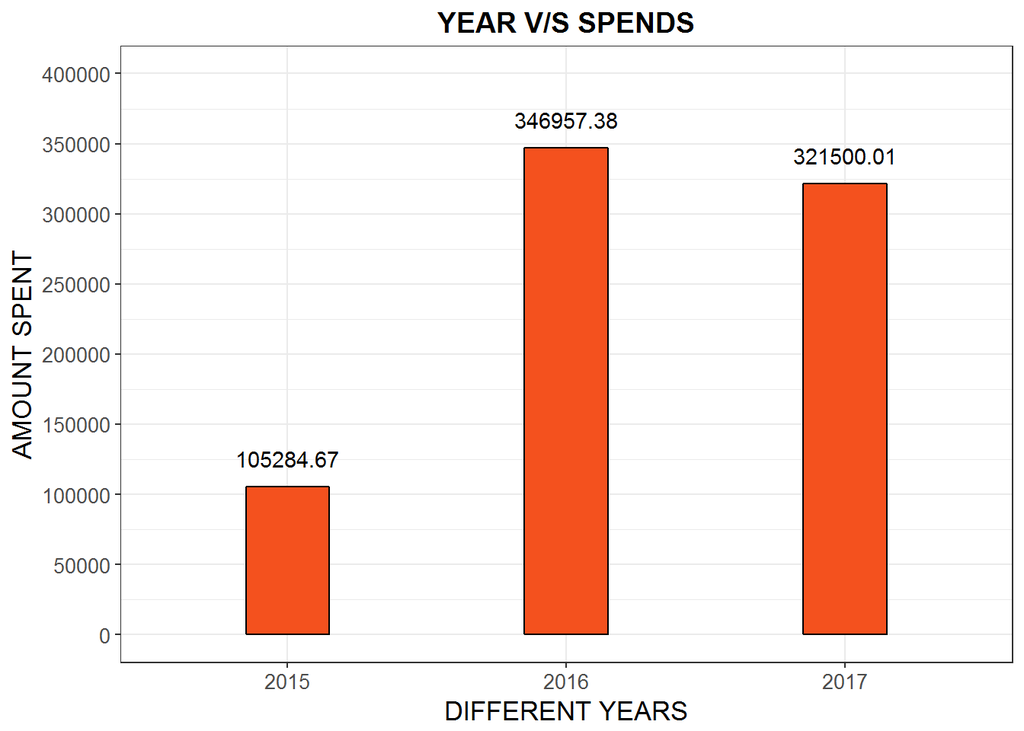

```r
expenses_by_year <- expenses %>%
  group_by(YEAR) %>%
  summarize(total=sum(AMOUNT),n=n())

ggplot(data=expenses_by_year,aes(x=YEAR,y=total))+
  geom_bar(stat="identity",color="black", width=0.3,fill="#F4511E")+
  geom_text(aes(label=total), vjust=-1.2) +
  scale_y_continuous(breaks = seq(0,400000,50000),limits =c(0,400000))+
  labs(y="AMOUNT SPENT",x="DIFFERENT YEARS",title="YEAR V/S SPENDS")+
  theme_bw()+
  theme(axis.text=element_text(size=10),axis.title=element_text(size=13))+
  theme(plot.title = element_text(hjust = 0.5,size = 14,face = "bold"))+
  ggsave(filename = "outputs/fig-1.png",width = 5,height = 4)
```

From here on, I will be considering the expenses of the 2017 only, as they are better categorized then the expenses of 2015 and 2016.

## 6. Category Varaiable :

The category variable captures the different type of categories I spend in.

```r
levels(expenses$CATEGORY)
```

```
##  [1] "ACCOMMODATION" "BILLS"         "ENTERTAINMENT" "FOOD & DRINKS"
##  [5] "GROCERIES"     "HEALTH"        "OTHER"         "PERSONAL CARE"
##  [9] "RECHARGE"      "SHOPPING"      "TRANSFER"      "TRAVEL"
## [13] "UNKNOWN"
```

Now lets calculate category wise spends:

```r
expenses <- subset(expenses,YEAR == "2017")
expenses_by_category <- expenses %>%
  group_by(CATEGORY)%>%
  summarize(total=sum(AMOUNT),n = n())%>%
  arrange(desc(total))

expenses_by_category
```

```
## # A tibble: 13 x 3
##         CATEGORY    total     n
##           <fctr>    <dbl> <int>
##  1 ACCOMMODATION 84500.00    10
##  2        TRAVEL 44626.81    79
##  3         BILLS 43070.16    28
##  4      TRANSFER 34710.00    13
##  5      SHOPPING 29188.46    13
##  6 FOOD & DRINKS 21110.59   336
##  7      RECHARGE 18649.17    45
##  8     GROCERIES 14894.22    32
##  9        HEALTH 14377.00     8
## 10       UNKNOWN 12144.00    16
## 11 ENTERTAINMENT  2522.60     6
## 12         OTHER  1500.00     2
## 13 PERSONAL CARE   207.00     1
```

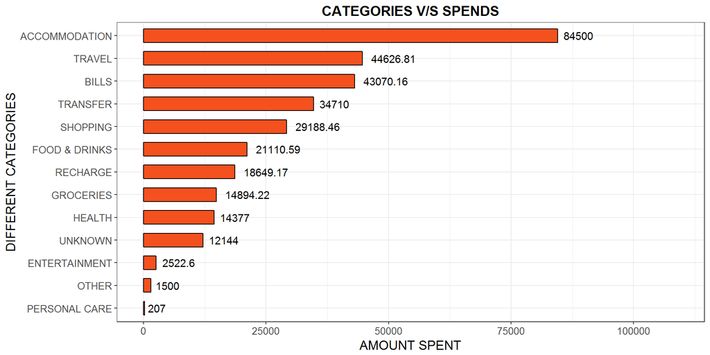

```r
ggplot(data=arrange(expenses_by_category,total),aes(x=reorder(CATEGORY,total),y=total))+
  geom_bar(stat="identity",color="black",fill="#F4511E",width = 0.6)+
  geom_text(aes(label=total), hjust=-0.2) +
  coord_flip()+
  scale_y_continuous(breaks = seq(0,101000,25000),limits = c(0,109000))+
  labs(y="AMOUNT SPENT",x="DIFFERENT CATEGORIES",title="CATEGORIES V/S SPENDS")+
  theme_bw()+
  theme(axis.text=element_text(size=10),axis.title=element_text(size=13))+
  theme(plot.title = element_text(hjust = 0.5,size = 14,face = "bold"))+
  ggsave(filename = "outputs/fig-2.png",width = 8,height = 5)
```

## 7. Month Varaible:

In this section I will be exploring my month wise expenses.

```r
expenses$MONTH <- factor(expenses$MONTH,ordered = TRUE, levels = c("Jan","Feb","Mar","Apr","May","Jun","Jul","Aug","Sep","Oct","Nov","Dec"))
expenses_by_month <- expenses %>%
  group_by(MONTH) %>%
  summarize(total = sum(AMOUNT),n=n())

expenses_by_month
```

```
## # A tibble: 12 x 3
##    MONTH    total     n
##    <ord>    <dbl> <int>
##  1   Jan 57239.88    52
##  2   Feb 44660.32    29
##  3   Mar 11148.60    62
##  4   Apr 29378.78    47
##  5   May 12690.50    31
##  6   Jun 22158.04    34
##  7   Jul 29169.73    36
##  8   Aug 18277.33    52
##  9   Sep 27506.33    61
## 10   Oct 35506.05    43
## 11   Nov 19487.50    71
## 12   Dec 14276.95    71
```

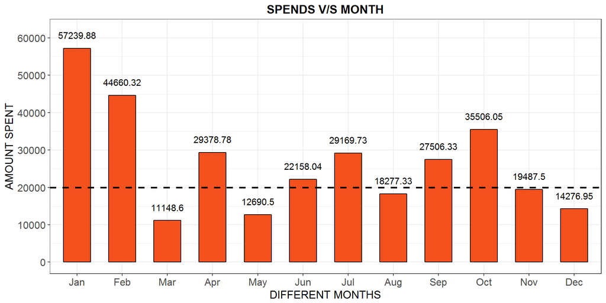

```r
ggplot(data=expenses_by_month,aes(x=MONTH,y=total))+
  geom_bar(stat="identity",color="black",fill="#F4511E",width=0.6)+
  geom_text(aes(label=total), vjust=-1.4) +
  labs(y="AMOUNT SPENT",x="DIFFERENT MONTHS",title="SPENDS V/S MONTH")+
  scale_y_continuous(breaks = seq(0,65000,10000),limits = c(0,62000))+
  geom_hline(yintercept = 20000,linetype=2,size=0.9,color="black")+
  theme_bw()+
  theme(axis.text=element_text(size=12),axis.title=element_text(size=13))+
  theme(plot.title = element_text(hjust = 0.5,size = 14,face = "bold"))+
  ggsave(filename = "outputs/fig-3.png",width = 10,height = 5)
```

Now lets combine month variable with category variable to explore the month wise category spends.

```r
expenses_by_month_category <- expenses %>%
  group_by(MONTH,CATEGORY) %>%
  summarize(total = sum(AMOUNT),
            n= n())
expenses_by_month_category
```

```
## # A tibble: 90 x 4
## # Groups:   MONTH [?]
##    MONTH      CATEGORY    total     n
##    <ord>        <fctr>    <dbl> <int>
##  1   Jan ACCOMMODATION  8000.00     1
##  2   Jan         BILLS 16353.97    11
##  3   Jan FOOD & DRINKS   660.00    13
##  4   Jan         OTHER   500.00     1
##  5   Jan      RECHARGE  2509.17     6
##  6   Jan      SHOPPING  4003.74     3
##  7   Jan      TRANSFER 16000.00     5
##  8   Jan        TRAVEL  7073.00     6
##  9   Jan       UNKNOWN  2140.00     6
## 10   Feb         BILLS  2854.82     3
## # ... with 80 more rows
```

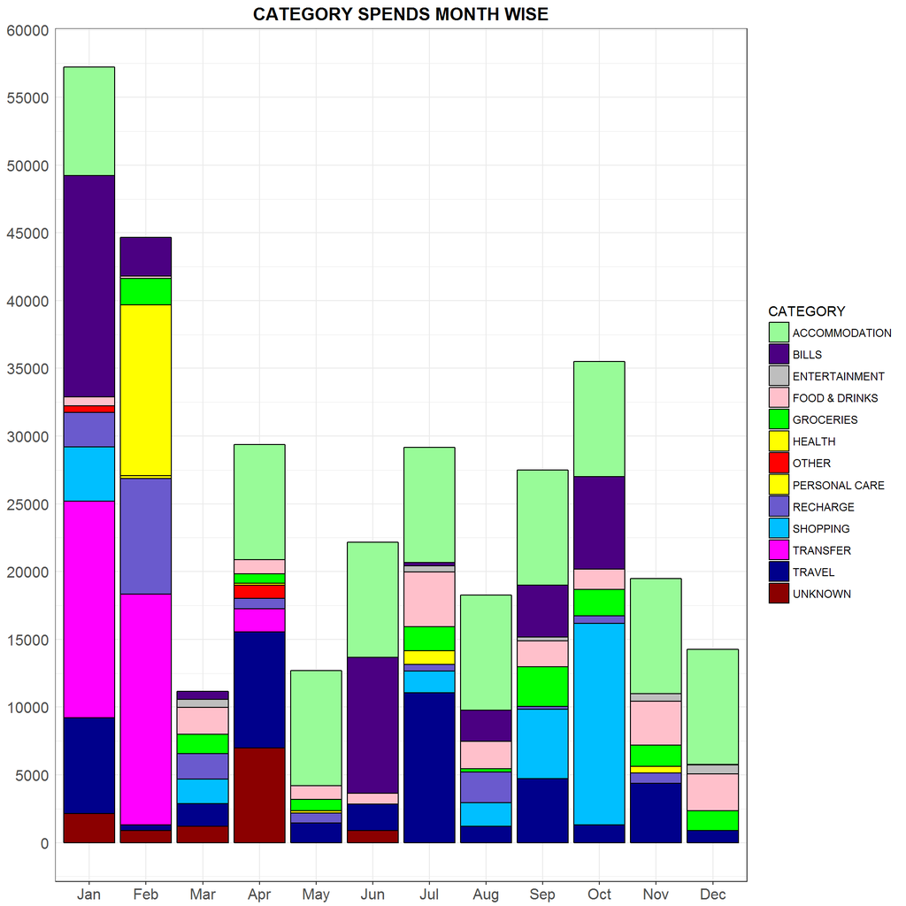

```r
p <- ggplot(data=expenses_by_month_category,aes(x=MONTH,y=total,fill=CATEGORY))+
  geom_bar(stat = "identity",color="black",position = "stack")+
  labs(y="AMOUNT SPENT",x="DIFFERENT MONTHS",title="CATEGORY SPENDS MONTH WISE")+
  scale_y_continuous(breaks = seq(0,60000,5000))+
  scale_fill_manual(values = c("#98FB98","#4B0082","grey","pink","green",
                               "yellow","red","yellow","#6A5ACD","#00BFFF","#FF00FF","darkblue","darkred"))+
  theme_bw()+
  theme(axis.text=element_text(size=12),axis.title=element_text(size=14,face="bold",hjust = -1))+
  theme(plot.title = element_text(hjust = 0.5,size = 14,face = "bold"),axis.title=element_blank(),axis.ticks.y=element_blank())+
  ggsave(filename = "outputs/fig-4.png",width = 7,height = 5)

p
```

To see a interactive plot of month wise category spends uncomment the code below and run the code chunk.

```r
#ggplotly(p)
```

## 8. Misc Facts

#### A). Total Number Of ATM Visits And Amount Drawn:

```r
totalAtmVisits_2017 <- subset(expensesTemp,expensesTemp$PLACE == "ATM" & expensesTemp$YEAR == "2017")
sprintf("Total Number Of Atm Visits: %s", nrow(totalAtmVisits_2017))
```

```
## [1] "Total Number Of Atm Visits: 8"
```

```r
sprintf("\nTotal Amount of Money Withdrawn: %s",sum(totalAtmVisits_2017$AMOUNT))
```

```
## [1] "\nTotal Amount of Money Withdrawn: 16100"
```

Now lets compare the above 2017 ATM stats to 2016 ATM stats to see whether **Demonitisation** played any role in number of ATM withdrawals.

```r
totalAtmVisits_2016 <- subset(expensesTemp,expensesTemp$PLACE == "ATM" & expensesTemp$YEAR == "2016")
sprintf("Total Number Of Atm Visits: %s", nrow(totalAtmVisits_2016))
```

```
## [1] "Total Number Of Atm Visits: 46"
```

```r
sprintf("Total Amount of Money Withdrawn: %s",sum(totalAtmVisits_2016$AMOUNT))
```

```
## [1] "Total Amount of Money Withdrawn: 100823"
```

The above stats clearly show that demonetization played a role in decreasing my number of ATM withdraws and increasing my card spends.

#### B). Total Number Of Cab Rides Taken Till Date.

```r
cabRides <- sum(with(expensesTemp,PLACE == "OLA" |  PLACE == "OLA CABS" | PLACE == "UBER" ))
sprintf("Total Number Of Cab Rides Taken: %s",cabRides)
```

```
## [1] "Total Number Of Cab Rides Taken: 45"
```

#### C). Total Number Of Tea Cups Consumed.

```r
teaCups <- sum(with(expensesTemp,PLACE == "HATTI KAPPI"| PLACE == "HATTI KAAPI" | PLACE == "TEA" ))
sprintf("Total Number Tea Cups Consumed: %s",teaCups)
```

```
## [1] "Total Number Tea Cups Consumed: 54"
```

#### D) Total Number Of Visits To UDUPI FOODS.

```r
udupiFoods <- sum(with(expensesTemp,PLACE == "UDIPI FOODS" | PLACE == "UDUPI FOODS"))
sprintf("Total Number Of Visits To UDUPI FOODS: %s",udupiFoods)
```

```
## [1] "Total Number Of Visits To UDUPI FOODS: 35"
```